# Multidimensional Poverty Index (MPI) - Mozambique DHS 2022-23

Global MPI, Alkire-Foster method (OPHI/UNDP) By Edmilson Filimone

17 October 2026

# What this script does

It computes the global MPI (Alkire-Foster method, OPHI/UNDP) https://10.1016/j.jpubeco.2010.11.006. The steps are:

1. Read the DHS files (PR = household members, BR = births)
2. Build the person-level information
3. Collapse to **household** level and create the 10 deprivation indicators (1 = deprived, 0 = not deprived)
4. Compute each household’s weighted deprivation score `c_i`
5. Identify the poor (`c_i >= k`, with k = 1/3)
6. Compute **H** (incidence), **A** (intensity) and **MPI = H x A**, with survey-design confidence intervals
7. Decompose by indicator and disaggregate by province and urban/rural
8. Run sensitive analysis and checks other k values

# 1. Packages and data

```r
library(haven)     # read Stata files
library(dplyr)     # data manipulation
library(survey)    # complex survey estimates
library(ggplot2)   # charts
library(knitr)     # tables
library(tidyr)     # reshaping for charts
library(scales)    # chart labels
```

```r
# ---- Files (edit if your names differ) ----
pr_file <- "data/MZPR82FL.dta"   # Household Member Recode
br_file <- "data/MZBR82FL.dta"   # Births Recode

# ---- MPI parameters ----
k <- 1/3                  # poverty cut-off (share of weighted deprivations)
school_age <- c(6, 14)    # school-age range for the attendance indicator
                          # (entry age 6 + 8 years of schooling; adjust if needed)

# ---- Indicator weights (global MPI) ----
weights <- c(
  nutrition    = 1/6, child_mort  = 1/6,           # Health
  years_school = 1/6, attendance  = 1/6,           # Education
  cooking      = 1/18, sanitation = 1/18, water   = 1/18,   # Living standards
  electricity  = 1/18, housing    = 1/18, assets  = 1/18
)
```

# 2. Read the data

## 2.1 Household member file (PR)

```r
# Variables
pr_vars <- c(
  # identifiers, design, weights
  "hv001", "hv002", "hv005", "hv021", "hv022", "hv024", "hv025",
  # member characteristics
  "hv102", "hv105", "hv108", "hv121", "hv042",
  # nutrition (children <5, women, men)
  "hc70", "hc71", "ha40", "hb40",
  # household characteristics
  "hv201", "hv204", "hv205", "hv225", "hv206", "hv226",
  "hv213", "hv214", "hv215","hv207", "hv208", "hv209",
  "hv210", "hv211", "hv212","hv221", "hv243a", "hv243c",
  "hv243e"
)

# Read data
pr <- read_dta(pr_file, col_select = any_of(pr_vars)) |>
  mutate(province = as.character(as_factor(hv024)),
         area     = as.character(as_factor(hv025))) |>
  mutate(across(-c(province, area), ~ as.numeric(zap_labels(.x))))

# If a variable is absent in this survey, create it as missing
absent <- setdiff(pr_vars, names(pr))
if (length(absent)) {
  message("Variables not found in PR (set to missing): ", paste(absent, collapse = ", "))
  for (v in absent) pr[[v]] <- NA_real_
}

# Keep usual household members (hv102 = 1, de jure) and build the household ID
pr <- pr |>
  filter(hv102 == 1) |>
  mutate(hh = paste(hv001, hv002, sep = "_"))

#cat("Persons:", nrow(pr), " | Households:", n_distinct(pr$hh))
```

## 2.2 Births file (BR) - for child mortality

```r
br <- read_dta(br_file, col_select = any_of(c("v001", "v002", "v008", "b3", "b5", "b7"))) |>
  mutate(across(everything(), ~ as.numeric(zap_labels(.x)))) |>
  mutate(hh = paste(v001, v002, sep = "_"))

# A child death counts if: child is dead (b5 = 0), died before age 18 (b7 < 216 months)
# and died in the 60 months before the interview (date of death = birth CMC + age at death)
hh_with_death <- br |>
  filter(b5 == 0, b7 < 216, (b3 + b7) > (v008 - 60)) |>
  distinct(hh) |>
  pull(hh)

#length(hh_with_death)   # nr of households with a child death in the last 5 years
```

# 3. Person-level variables

```r
pr <- pr |>
  mutate(
    # ---- Nutrition (anthropometry values are stored x100; >= 9990 = flagged/missing)
    haz   = ifelse(hc70 < 9990, hc70 / 100, NA),     # height-for-age z-score (child)
    waz   = ifelse(hc71 < 9990, hc71 / 100, NA),     # weight-for-age z-score (child)
    bmi_w = ifelse(ha40 < 9990, ha40 / 100, NA),     # women BMI
    bmi_m = ifelse(hb40 < 9990, hb40 / 100, NA),     # men BMI
    bmi   = coalesce(bmi_w, bmi_m),
    z_min = suppressWarnings(pmin(haz, waz, na.rm = TRUE)),   # worst of HAZ/WAZ
    z_min = ifelse(is.infinite(z_min), NA, z_min),

    nut_measured = !is.na(z_min) | !is.na(bmi),
    nut_dep      = (!is.na(z_min) & z_min < -2) | (!is.na(bmi) & bmi < 18.5),

    # ---- Education
    yrs = ifelse(hv108 %in% c(98, 99), NA, hv108)    # years of schooling
  )

# School Attendance
attend_code <- if (2 %in% pr$hv121) 2 else 1
pr <- pr |> mutate(attending = ifelse(hv121 %in% c(0, attend_code), as.numeric(hv121 == attend_code), NA))
```

# 4. Household-level indicators

## 4.1 Indicators built from household members (nutrition, schooling, attendance)

```r
lo <- school_age[1]; hi <- school_age[2]

hh_persons <- pr |>
  group_by(hh) |>
  summarise(
    hhsize = n(),

    # NUTRITION: deprived if ANY measured eligible member is undernourished.
    # Anthropometry covers a sub-sample of households (hv042 = 1). Households outside
    # the sub-sample are missing; selected households with no eligible person = not deprived.
    nut_sel = ifelse(all(is.na(hv042)), any(nut_measured), first(hv042) == 1),
    dep_nutrition = case_when(
      !nut_sel                          ~ NA_real_,
      any(nut_dep & nut_measured)       ~ 1,
      TRUE                              ~ 0
    ),

    # YEARS OF SCHOOLING: deprived if NO member aged 10+ has 6+ years of schooling
    dep_years_school = {
      e <- hv105 >= 10
      if (!any(e)) 0
      else if (any(yrs[e] >= 6, na.rm = TRUE)) 0
      else if (any(!is.na(yrs[e]))) 1
      else NA_real_
    },

    # SCHOOL ATTENDANCE: deprived if ANY school-age child is not attending school
    dep_attendance = {
      e <- hv105 >= lo & hv105 <= hi
      if (!any(e)) 0
      else if (any(attending[e] == 0, na.rm = TRUE)) 1
      else if (any(!is.na(attending[e]))) 0
      else NA_real_
    },
    .groups = "drop"
  )
```

## 4.2 Indicators built from household characteristics

```r
hh_chars <- pr |>
  group_by(hh) |>
  slice(1) |>
  ungroup() |>
  mutate(
    # COOKING FUEL: solid fuels (coal, charcoal, wood, straw, crop residue, dung) = deprived
    dep_cooking = case_when(
      hv226 %in% 6:11          ~ 1,
      hv226 %in% c(1:5, 95)    ~ 0,     # 95 = no food cooked in household
      TRUE                     ~ NA_real_
    ),

    # SANITATION: deprived if facility is unimproved OR shared
    san_improved = hv205 %in% c(11:15, 21, 22, 41, 51),
    san_known    = !is.na(hv205) & hv205 != 99,
    dep_sanitation = case_when(
      san_known & hv225 %in% 1           ~ 1,   # shared facility
      san_known & !san_improved          ~ 1,
      san_known & san_improved           ~ 0,
      TRUE                               ~ NA_real_
    ),

    # DRINKING WATER: deprived if unimproved source OR round trip >= 30 minutes
    wat_improved = hv201 %in% c(11:14, 21, 31, 41, 51, 61, 62, 71),
    wat_known    = !is.na(hv201) & hv201 != 99,
    wat_time     = ifelse(hv204 %in% c(998, 999), NA, ifelse(hv204 == 996, 0, hv204)),
    dep_water = case_when(
      wat_known & !wat_improved                    ~ 1,
      wat_known & wat_improved & wat_time >= 30    ~ 1,
      wat_known & wat_improved & !is.na(wat_time)  ~ 0,
      TRUE                                         ~ NA_real_
    ),

    # ELECTRICITY
    dep_electricity = case_when(hv206 == 0 ~ 1, hv206 == 1 ~ 0, TRUE ~ NA_real_),

    # HOUSING: deprived if floor is natural, OR roof/wall are natural or rudimentary
    floor_dep = case_when(hv213 %in% c(10, 11, 12) ~ 1, hv213 %in% c(13:95) ~ 0, TRUE ~ NA_real_),
    roof_dep  = case_when(hv215 < 30 ~ 1, hv215 >= 30 & hv215 < 96 ~ 0, TRUE ~ NA_real_),
    wall_dep  = case_when(hv214 < 30 ~ 1, hv214 >= 30 & hv214 < 96 ~ 0, TRUE ~ NA_real_),
    dep_housing = case_when(
      floor_dep %in% 1 | roof_dep %in% 1 | wall_dep %in% 1 ~ 1,
      !is.na(floor_dep) & !is.na(roof_dep) & !is.na(wall_dep) ~ 0,
      TRUE ~ NA_real_
    ),
    dummy = NA
  ) |>
  select(-dummy)

# ASSETS: deprived if the household owns at most ONE of: radio, TV, telephone
# (landline or mobile), computer, animal cart, bicycle, motorbike, refrigerator
# AND owns no car/truck
yn <- function(x) ifelse(x %in% c(0, 1), x, NA_real_)   # keep 0/1, others -> NA
hh_chars <- hh_chars |>
  mutate(
    phone  = pmax(yn(hv221), yn(hv243a), na.rm = TRUE),
    phone  = ifelse(is.infinite(phone), NA, phone),
    n_small = rowSums(cbind(yn(hv207), yn(hv208), yn(hv209), yn(hv210),
                            yn(hv211), phone, yn(hv243c), yn(hv243e)), na.rm = TRUE),
    n_known = rowSums(!is.na(cbind(yn(hv207), yn(hv208), yn(hv209), yn(hv210),
                                   yn(hv211), phone, yn(hv243c), yn(hv243e)))),
    dep_assets = case_when(
      yn(hv212) %in% 1 ~ 0,          # owns car/truck
      n_small >= 2     ~ 0,
      n_known == 0     ~ NA_real_,
      TRUE             ~ 1
    )
  ) |>
  select(hh, hv001, hv005, hv021, hv022, province, area,
         starts_with("dep_"))
```

## 4.3 Child mortality and final household file

```r
hh <- hh_chars |>
  left_join(hh_persons, by = "hh") |>
  mutate(
    # CHILD MORTALITY: deprived if any child died (<18 y) in the last 5 years.
    # Households without such a death (or without women interviewed) = not deprived.
    dep_child_mort = as.numeric(hh %in% hh_with_death),
    hh_weight      = hv005 / 1e6,
    person_weight  = hh_weight * hhsize       # so H = share of PEOPLE
  )

dep_cols <- paste0("dep_", names(weights))
```

## 4.4 Analysis sample

The global MPI keeps only households with valid information in all 10 indicators (missing information by indicator is reported in section 9).

```r
mpi_data <- hh |> filter(if_all(all_of(dep_cols), ~ !is.na(.x)))
cat("Households in total:", nrow(hh), "\n",
    "Households with complete information (analysis sample):", nrow(mpi_data))
```

```
## Households in total: 14249
##  Households with complete information (analysis sample): 6418
```

# 5. Deprivation score and poverty status

```r
# c_i = sum of weights x deprivations
dep_matrix <- as.matrix(mpi_data[, dep_cols])
mpi_data$score <- as.vector(dep_matrix %*% weights[sub("dep_", "", dep_cols)])

# Poor if c_i >= k  (small tolerance avoids floating-point problems at exactly 1/3)
mpi_data$poor   <- as.numeric(mpi_data$score >= k - 1e-10)

# Censored score: the score of non-poor households is set to 0
mpi_data$c_cens <- mpi_data$score * mpi_data$poor

# Censored indicators: deprived in indicator j AND multidimensionally poor
for (v in dep_cols) mpi_data[[paste0("cens_", v)]] <- mpi_data[[v]] * mpi_data$poor

# Survey design: PSU (hv021), strata (hv022), person weights
options(survey.lonely.psu = "adjust")

des <- svydesign(ids = ~hv021, strata = ~hv022, weights = ~person_weight,
                 data = mpi_data, nest = TRUE)
```

# 6. Calculations for the report

This chunk computes every number used in the cards and charts below.

```r
# ---- Headline measures --------------------------------------------------
H   <- svymean(~poor,   des)
MPI <- svymean(~c_cens, des)
A   <- svyratio(~c_cens, ~poor, des)      # A = MPI / H

H_pct  <- coef(H) * 100
A_pct  <- coef(A) * 100
MPI_v  <- coef(MPI)
H_ci   <- confint(H) * 100
A_ci   <- confint(A) * 100
MPI_ci <- confint(MPI)

# ---- Indicator names, dimensions and colours -------------------------------
ind_names <- sub("dep_", "", dep_cols)
dimension <- c(nutrition = "Health", child_mort = "Health",
               years_school = "Education", attendance = "Education",
               cooking = "Living standards", sanitation = "Living standards",
               water = "Living standards", electricity = "Living standards",
               housing = "Living standards", assets = "Living standards")
dim_cols  <- c("Health" = "#e34a33", "Education" = "#2c7fb8", "Living standards" = "#31a354")
pretty    <- c(nutrition = "Nutrition", child_mort = "Child mortality",
               years_school = "Years of schooling", attendance = "School attendance",
               cooking = "Cooking fuel", sanitation = "Sanitation", water = "Drinking water",
               electricity = "Electricity", housing = "Housing", assets = "Assets")

# ---- By indicator --------------------------------------------------------
by_ind <- do.call(rbind, lapply(ind_names, function(j) {
  unc <- coef(svymean(as.formula(paste0("~dep_", j)),      des))   # uncensored
  cen <- coef(svymean(as.formula(paste0("~cens_dep_", j)), des))   # censored
  data.frame(indicator = j, label = pretty[[j]], dimension = dimension[[j]],
             weight = weights[[j]],
             uncensored = unc * 100, censored = cen * 100,
             contribution = 100 * weights[[j]] * cen / MPI_v)
}))

by_dim <- by_ind |> group_by(dimension) |>
  summarise(contribution = sum(contribution), .groups = "drop")

# ---- By province -----------------------------------------------------------
prov <- svyby(~poor + c_cens, ~province, des, svymean, vartype = "ci") |>
  transmute(province, H_pct = 100 * poor, H_low = 100 * ci_l.poor, H_upp = 100 * ci_u.poor,
            A_pct = 100 * c_cens / poor,
            MPI = c_cens, MPI_low = ci_l.c_cens, MPI_upp = ci_u.c_cens) |>
  arrange(desc(MPI))

cens_vars <- paste0("cens_dep_", ind_names)
prov_dim <- svyby(as.formula(paste("~", paste(cens_vars, collapse = "+"))),
                  ~province, des, svymean) |>
  select(province, all_of(cens_vars)) |>
  pivot_longer(-province, names_to = "indicator", values_to = "cens") |>
  mutate(indicator = sub("cens_dep_", "", indicator),
         dimension = dimension[indicator],
         part      = cens * weights[indicator]) |>      # part of the province MPI
  group_by(province, dimension) |>
  summarise(part = sum(part), .groups = "drop")

# ---- By area (urban / rural) ------------------------------------------------
area <- svyby(~poor + c_cens, ~area, des, svymean, vartype = "ci") |>
  transmute(area, H_pct = 100 * poor, A_pct = 100 * c_cens / poor,
            MPI = c_cens, MPI_low = ci_l.c_cens, MPI_upp = ci_u.c_cens)

# ---- Robustness to the poverty cut-off ---------------------------------------
robust <- do.call(rbind, lapply(c(0.20, 1/3, 0.50), function(kk) {
  mpi_data$p_k <- as.numeric(mpi_data$score >= kk - 1e-10)
  mpi_data$c_k <- mpi_data$score * mpi_data$p_k
  d  <- svydesign(ids = ~hv021, strata = ~hv022, weights = ~person_weight,
                  data = mpi_data, nest = TRUE)
  Hk <- coef(svymean(~p_k, d)); Mk <- coef(svymean(~c_k, d))
  data.frame(k = paste0("k = ", round(kk * 100), "%"),
             H = 100 * Hk, A = 100 * Mk / Hk, MPI = Mk)
}))

# Chart theme
theme_mpi <- theme_minimal(base_size = 12) +
  theme(plot.title = element_text(face = "bold"), panel.grid.minor = element_blank(),
        legend.position = "bottom")
```

# 7. Results

MPI

0.338

95% CI: 0.323 - 0.353

Incidence

62.1%

of people are MPI-poor. 95% CI: 59.9 - 64.3

Intensity

54.5%

avg. share of deprivations among the poor. 95% CI: 53.6 - 55.4

Households analysed

6,418

45% of all households (complete information)

Highest MPI

nampula

MPI 0.438 | H = 76.6%

Lowest MPI

cidade de maputo

MPI 0.025 | H = 6.7%

Rural MPI

0.440

H = 78.6%

Urban MPI

0.138

H = 29.6%

**How to read this.** A household is *MPI-poor* when its weighted deprivation score is at least 33.3% (k = 1/3). **H** is the share of people who are poor, **A** is how many deprivations the poor face on average, and **MPI = H x A**. Estimates are person-weighted and account for the survey design (PSU, strata).

## 7.1 What drives poverty? Contribution by indicator

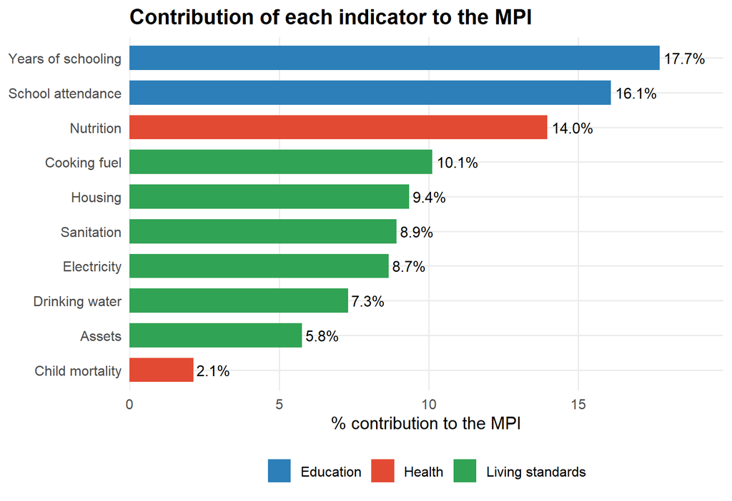

```r
ggplot(by_ind, aes(x = reorder(label, contribution), y = contribution, fill = dimension)) +
  geom_col(width = 0.7) +
  geom_text(aes(label = sprintf("%.1f%%", contribution)), hjust = -0.1, size = 3.6) +
  scale_fill_manual(values = dim_cols, name = NULL) +
  scale_y_continuous(expand = expansion(mult = c(0, 0.12))) +
  coord_flip() +
  labs(x = NULL, y = "% contribution to the MPI",
       title = "Contribution of each indicator to the MPI") +
  theme_mpi
```

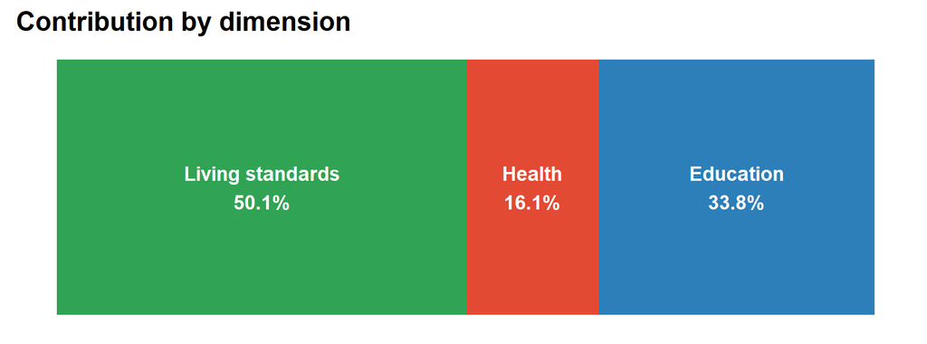

```r
ggplot(by_dim, aes(x = 1, y = contribution, fill = dimension)) +
  geom_col(width = 0.5) +
  geom_text(aes(label = sprintf("%s\n%.1f%%", dimension, contribution)),
            position = position_stack(vjust = 0.5), colour = "white", size = 3.8, fontface = "bold") +
  scale_fill_manual(values = dim_cols, guide = "none") +
  coord_flip() +
  labs(x = NULL, y = NULL, title = "Contribution by dimension") +
  theme_mpi + theme(axis.text = element_blank(), panel.grid = element_blank())
```

## 7.2 Who is deprived? Uncensored vs censored headcount

Uncensored = share of people deprived in the indicator. Censored = share of people who are deprived in the indicator **and** MPI-poor.

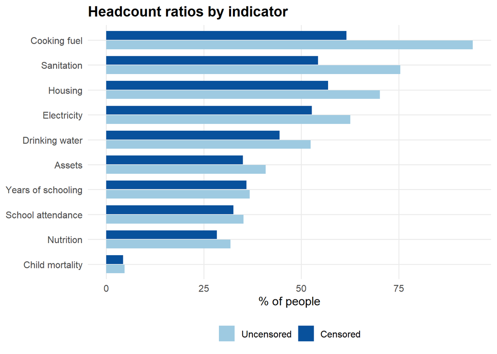

```r
by_ind |>
  select(label, dimension, Uncensored = uncensored, Censored = censored) |>
  pivot_longer(c(Uncensored, Censored), names_to = "type", values_to = "pct") |>
  mutate(type = factor(type, levels = c("Uncensored", "Censored"))) |>
  ggplot(aes(x = reorder(label, pct), y = pct, fill = type)) +
  geom_col(position = position_dodge(width = 0.75), width = 0.7) +
  scale_fill_manual(values = c(Uncensored = "#9ecae1", Censored = "#08519c"), name = NULL) +
  coord_flip() +
  labs(x = NULL, y = "% of people", title = "Headcount ratios by indicator") +
  theme_mpi
```

```r
by_ind |>
  transmute(Indicator = label, Dimension = dimension, Weight = round(weight, 3),
            `Uncensored (%)` = uncensored, `Censored (%)` = censored,
            `Contribution (%)` = contribution) |>
  flextable::as_flextable()|>
  flextable::theme_vanilla()|>
  flextable::delete_rows(i = 2, part = "header")|>
  flextable::add_header_row(values = c("","Indicator-level results", ""), colwidths = c(2,3,1))
```

| Indicator | Dimension | Indicator-level results Weight | Indicator-level results Uncensored (%) | Indicator-level results Censored (%) | Contribution (%) |
| --- | --- | --- | --- | --- | --- |
| Nutrition | Health | 0.2 | 31.8 | 28.3 | 14.0 |
| Child mortality | Health | 0.2 | 4.7 | 4.3 | 2.1 |
| Years of schooling | Education | 0.2 | 36.8 | 35.9 | 17.7 |
| School attendance | Education | 0.2 | 35.2 | 32.6 | 16.1 |
| Cooking fuel | Living standards | 0.1 | 93.9 | 61.6 | 10.1 |
| Sanitation | Living standards | 0.1 | 75.4 | 54.3 | 8.9 |
| Drinking water | Living standards | 0.1 | 52.4 | 44.4 | 7.3 |
| Electricity | Living standards | 0.1 | 62.6 | 52.7 | 8.7 |
| Housing | Living standards | 0.1 | 70.1 | 56.9 | 9.4 |
| Assets | Living standards | 0.1 | 40.9 | 35.0 | 5.8 |

n: 10

## 7.3 Distribution of the deprivation score

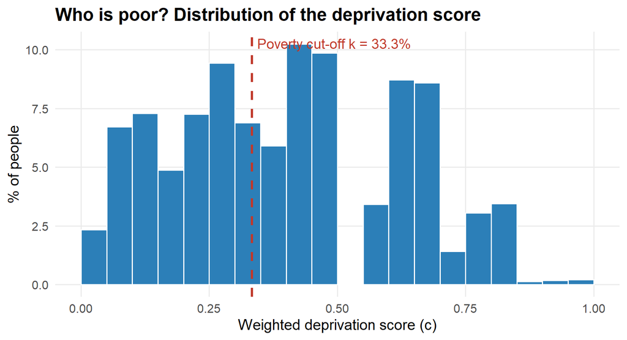

```r
ggplot(mpi_data, aes(x = score, weight = person_weight,
                     y = after_stat(count / sum(count) * 100))) +
  geom_histogram(binwidth = 0.05, boundary = 0, fill = "#2c7fb8", colour = "white") +
  geom_vline(xintercept = k, colour = "#c0392b", linetype = "dashed", linewidth = 0.9) +
  annotate("text", x = k + 0.01, y = Inf, vjust = 1.6, hjust = 0, colour = "#c0392b",
           label = paste0("Poverty cut-off k = ", round(k * 100, 1), "%")) +
  labs(x = "Weighted deprivation score (c)", y = "% of people",
       title = "Who is poor? Distribution of the deprivation score") +
  theme_mpi
```

## 7.4 By province

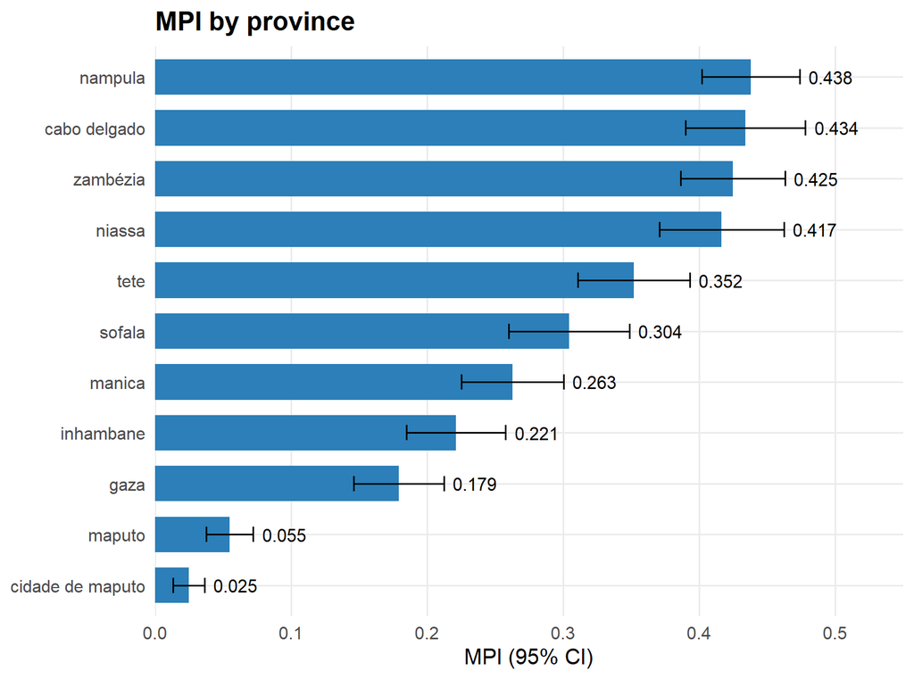

```r
ggplot(prov, aes(x = reorder(province, MPI), y = MPI)) +
  geom_col(fill = "#2c7fb8", width = 0.7) +
  geom_errorbar(aes(ymin = MPI_low, ymax = MPI_upp), width = 0.3) +
  geom_text(aes(y = MPI_upp, label = sprintf("%.3f", MPI)), hjust = -0.2, size = 3.5) +
  scale_y_continuous(expand = expansion(mult = c(0, 0.15))) +
  coord_flip() +
  labs(x = NULL, y = "MPI (95% CI)", title = "MPI by province") +
  theme_mpi
```

```r
# Map

# Palette
red_palette <- c("#FFF7F3", "#FC8D73", "#F57B8A", "#DC4D4D")

ggplot() +
    # Layers
    geom_sf(data = shadow, color="#636363")+
    # Boundaries
    geom_sf(data=layer_province,
            aes(fill = mpi_cat),
            alpha=0.93)+
    scale_fill_manual(values = red_palette,
                      guide=guide_legend(position="left",
                                         title = "MPI (%)",
                                         theme = theme(
                                           legend.title = element_text(size = 10, lineheight = 5),
                                           legend.margin = margin(200,0,0,5),
                                           legend.key.height = unit(12,"pt"),
                                           legend.key.width =  unit(12,"pt"),
                                           legend.key.spacing.y = unit(x = 5, units = "pt"))))+
    # Bubbles
    geom_sf(data=layer_centroids,
            aes(size=MPI),
            colour="skyblue",
            alpha=0.5,
            show.legend = FALSE)+
    scale_size_continuous(range = c(8, 16)) +
    # Labels para bubbles
    geom_sf_text(data = layer_centroids,
                 aes(label=label),
                 size=4,
                 fontface="bold",
                 ) +
    # label para provinces
    geom_sf_text(data = filter(layer_province,
                               ADM1_PT != "Maputo City" & ADM1_PT != "Zambezia"),
                 aes(label= ADM1_PT),
                 size=3,
                 nudge_y =.8)+
      # Labels para Maputo e Zambezia (ajustes de posicao)
    geom_sf_text(data = filter(layer_province, ADM1_PT == "Maputo City"),
                 aes(label= ADM1_PT),
                 size=3,
                 nudge_y =.2,
                 nudge_x = 1.1)+
    geom_sf_text(data = filter(layer_province, ADM1_PT == "Zambezia"),
                 aes(label= ADM1_PT),
                 size=3,
                 nudge_y =.8,
                 nudge_x = 0.9)+
    theme_void(base_size = 11,
               base_family = "Roboto")
```

[figure not shown]

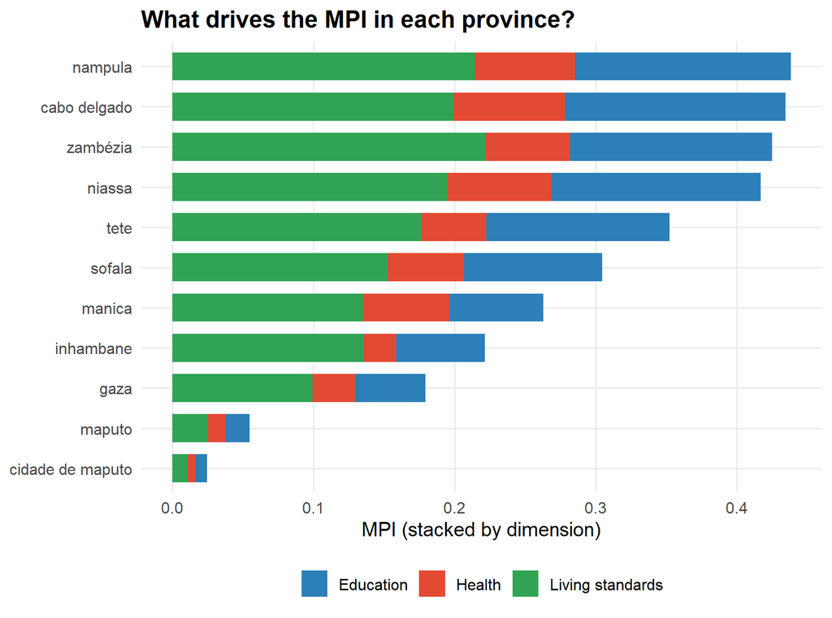

```r
prov_dim |>
  mutate(province = factor(province, levels = prov$province[order(prov$MPI)])) |>
  ggplot(aes(x = province, y = part, fill = dimension)) +
  geom_col(width = 0.7) +
  scale_fill_manual(values = dim_cols, name = NULL) +
  coord_flip() +
  labs(x = NULL, y = "MPI (stacked by dimension)",
       title = "What drives the MPI in each province?") +
  theme_mpi
```

```r
prov |>
  transmute(Province = province,
            `H (%)` = H_pct,
            `A (%)` = A_pct,
            `MPI (95% CI)` = paste0(round(100*MPI,1)," (",round(100*MPI_low,1),"-",round(100*MPI_upp,1),")")) |>
  flextable::as_flextable(max_row = 11)|>
  flextable::theme_vanilla()|>
  flextable::delete_rows(i = 2, part = "header")
```

| Province | H (%) | A (%) | MPI (95% CI) |
| --- | --- | --- | --- |
| nampula | 76.6 | 57.2 | 43.8 (40.2-47.4) |
| cabo delgado | 76.6 | 56.7 | 43.4 (39-47.8) |
| zambézia | 78.7 | 54.0 | 42.5 (38.6-46.3) |
| niassa | 73.5 | 56.7 | 41.7 (37.1-46.2) |
| tete | 64.7 | 54.4 | 35.2 (31.1-39.3) |
| sofala | 56.8 | 53.6 | 30.4 (26-34.9) |
| manica | 51.2 | 51.4 | 26.3 (22.5-30) |
| inhambane | 49.1 | 45.1 | 22.1 (18.5-25.8) |
| gaza | 40.2 | 44.6 | 17.9 (14.6-21.2) |
| maputo | 12.4 | 44.1 | 5.5 (3.7-7.2) |
| cidade de maputo | 6.7 | 36.6 | 2.5 (1.3-3.6) |

n: 11

## 7.5 Urban vs rural

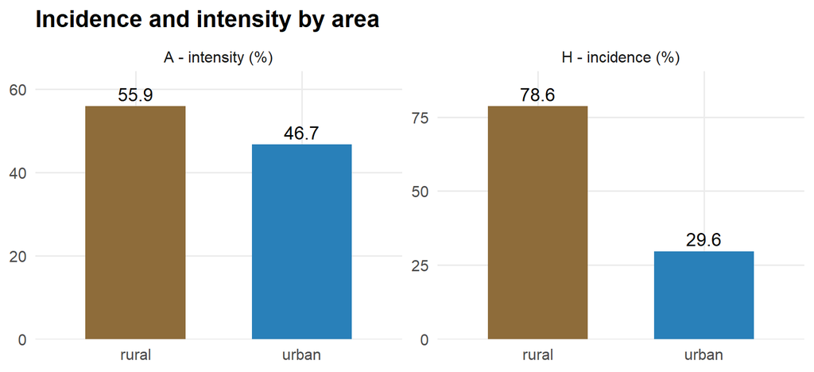

```r
area |>
  pivot_longer(c(H_pct, A_pct), names_to = "measure", values_to = "value") |>
  mutate(measure = recode(measure, H_pct = "H - incidence (%)", A_pct = "A - intensity (%)")) |>
  ggplot(aes(x = area, y = value, fill = area)) +
  geom_col(width = 0.6, show.legend = FALSE) +
  geom_text(aes(label = sprintf("%.1f", value)), vjust = -0.4) +
  facet_wrap(~measure, scales = "free_y") +
  scale_fill_manual(values = c("#8e6c3a", "#2980b9", "#7f8c8d")[seq_len(nrow(area))]) +
  scale_y_continuous(expand = expansion(mult = c(0, 0.15))) +
  labs(x = NULL, y = NULL, title = "Incidence and intensity by area") +
  theme_mpi
```

# 8. Sensitive Analysis: other poverty cut-offs

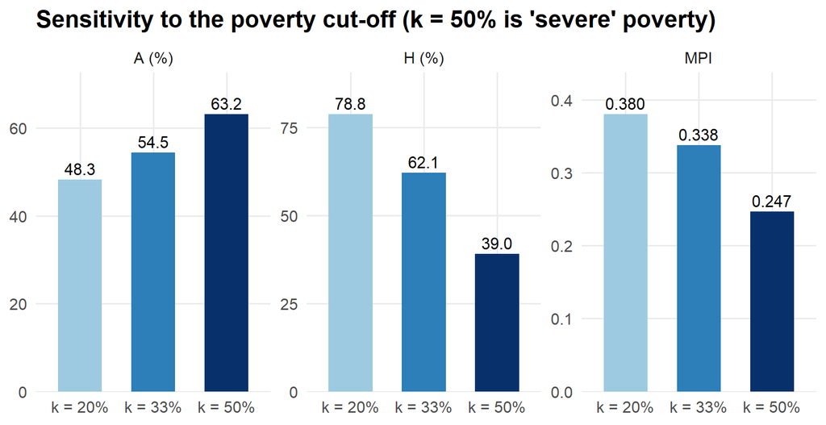

```r
robust |>
  pivot_longer(c(H, A, MPI), names_to = "measure", values_to = "value") |>
  mutate(measure = recode(measure, H = "H (%)", A = "A (%)", MPI = "MPI")) |>
  ggplot(aes(x = k, y = value, fill = k)) +
  geom_col(width = 0.6, show.legend = FALSE) +
  geom_text(aes(label = ifelse(measure == "MPI", sprintf("%.3f", value), sprintf("%.1f", value))),
            vjust = -0.4, size = 3.5) +
  facet_wrap(~measure, scales = "free_y") +
  scale_fill_manual(values = c("#9ecae1", "#2c7fb8", "#08306b")) +
  scale_y_continuous(expand = expansion(mult = c(0, 0.15))) +
  labs(x = NULL, y = NULL, title = "Sensitivity to the poverty cut-off (k = 50% is 'severe' poverty)") +
  theme_mpi
```

# 9. Data quality: missing information

The global MPI keeps only households with valid information in all 10 indicators.

```r
miss <- sapply(hh[dep_cols], function(x) round(100 * mean(is.na(x)), 1))
data.frame(Indicator = pretty[sub("dep_", "", names(miss))], `% households missing` = miss,
           check.names = FALSE, row.names = NULL) |>
 flextable::flextable(cwidth = 2)
```

| Indicator | % households missing |
| --- | --- |
| Nutrition | 53.8 |
| Child mortality | 0.0 |
| Years of schooling | 0.1 |
| School attendance | 0.0 |
| Cooking fuel | 0.2 |
| Sanitation | 0.0 |
| Drinking water | 2.3 |
| Electricity | 0.0 |
| Housing | 0.1 |
| Assets | 0.0 |

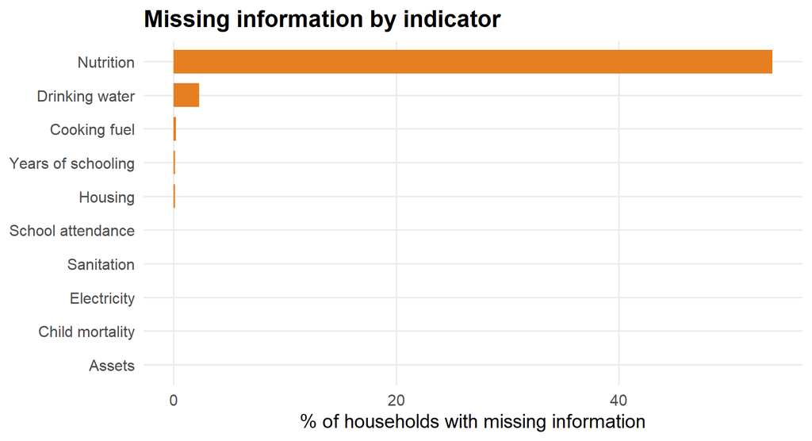

```r
data.frame(label = pretty[sub("dep_", "", names(miss))], pct = miss) |>
  ggplot(aes(x = reorder(label, pct), y = pct)) +
  geom_col(fill = "#e67e22", width = 0.7) +
  coord_flip() +
  labs(x = NULL, y = "% of households with missing information",
       title = "Missing information by indicator") +
  theme_mpi
```

# 10. Notes

- **Compare with the official global MPI for Mozambique** (OPHI/UNDP). Small differences are expected because of the simplifications below.
- Nutrition is measured in a subsample of households, so the analysis sample is mostly that subsample (as in the global MPI).
- Bottled water is treated as an improved source (OPHI also checks the source used for other purposes).
- BMI < 18.5 is applied to everyone aged 15+; OPHI uses BMI-for-age for adolescents aged 15-19.
- Child mortality uses the birth histories of interviewed women; households without an interviewed woman are treated as not deprived.
- “Other” categories (code 96) in housing materials are treated as missing.